# R Commands for Applied Statistics

Math 260 · mosaic and ggformula graphics

**NoteHow to read a command**

Almost everything below follows one pattern:

```
goal(y ~ x, data = mydata)
```

The `~` is read **“described by”** or **“depends on”**. When there is only one variable, leave the left side off: `~ x`.

For plots, the left side of `~` is the **vertical** axis and the right side is the **horizontal** axis. Remember that **x** is the e**X**planatory variable, so it goes on the right.

Use `|>` to send a plot into another plotting command. You will see `%>%` in older code and in answers from AI assistants — it does the same thing, but use `|>` in this course.

You will see `|` inside a formula later in this document (for example `~ Height | Sex ~ .`) — that is a different thing entirely. It only shows up when splitting a plot of a **quantitative** variable into panels by group. For two categorical variables, stick with `y ~ x`.

# Getting started

## Load the packages you need

Put this at the top of every Quarto file. Without it, R will not know what `favstats()` or `gf_histogram()` mean.

```r
library(mosaic)
library(Lock5Data)
```

packages, library, load, mosaic, ggformula, start

## Get help on a command

```r
?favstats
help(gf_histogram)
```

help, documentation, arguments, options, stuck

## See how big a dataset is

```r
dim(StudentSurvey)
```

```
[1] 362  17
```

The first number is rows (cases), the second is columns (variables). Use `nrow()` if you want only the row count.

```r
nrow(StudentSurvey)
```

```
[1] 362
```

dimensions, size, how many rows, how many columns, cases, dim, nrow

## See what is in a dataset

```r
names(StudentSurvey)
```

```
 [1] "Year"       "Sex"        "Smoke"      "Award"      "HigherSAT"
 [6] "Exercise"   "TV"         "Height"     "Weight"     "Siblings"
[11] "BirthOrder" "VerbalSAT"  "MathSAT"    "SAT"        "GPA"
[16] "Pulse"      "Piercings"
```

```r
head(StudentSurvey)
```

```
       Year Sex Smoke   Award HigherSAT Exercise TV Height Weight Siblings
1    Senior   M    No Olympic      Math       10  1     71    180        4
2 Sophomore   F   Yes Academy      Math        4  7     66    120        2
3 FirstYear   M    No   Nobel      Math       14  5     72    208        2
4    Junior   M    No   Nobel      Math        3  1     63    110        1
5 Sophomore   F    No   Nobel    Verbal        3  3     65    150        1
6 Sophomore   F    No   Nobel    Verbal        5  4     65    114        2
  BirthOrder VerbalSAT MathSAT  SAT  GPA Pulse Piercings
1          4       540     670 1210 3.13    54         0
2          2       520     630 1150 2.50    66         3
3          1       550     560 1110 2.55   130         0
4          1       490     630 1120 3.10    78         0
5          1       720     450 1170 2.70    40         6
6          2       600     550 1150 3.20    80         4
```

`View(StudentSurvey)` opens a spreadsheet view. Type it at the console — do not put it in a code chunk.

variables, columns, look at data, dataset, view, head, names

# One categorical variable

## Count how many are in each category

```r
tally(~ Award, data = StudentSurvey)
```

```
Award
Academy   Nobel Olympic
     31     149     182
```

table, frequency, counts, how many

## Show percents or proportions instead of counts

```r
tally(~ Award, data = StudentSurvey,
      format = "percent")
```

```
Award
Academy   Nobel Olympic
  8.564  41.160  50.276
```

```r
tally(~ Award, data = StudentSurvey,
      format = "proportion")
```

```
Award
Academy   Nobel Olympic
0.08564 0.41160 0.50276
```

Add `margins = TRUE` to include a total row.

percent, proportion, relative frequency, share

## Bar chart of counts

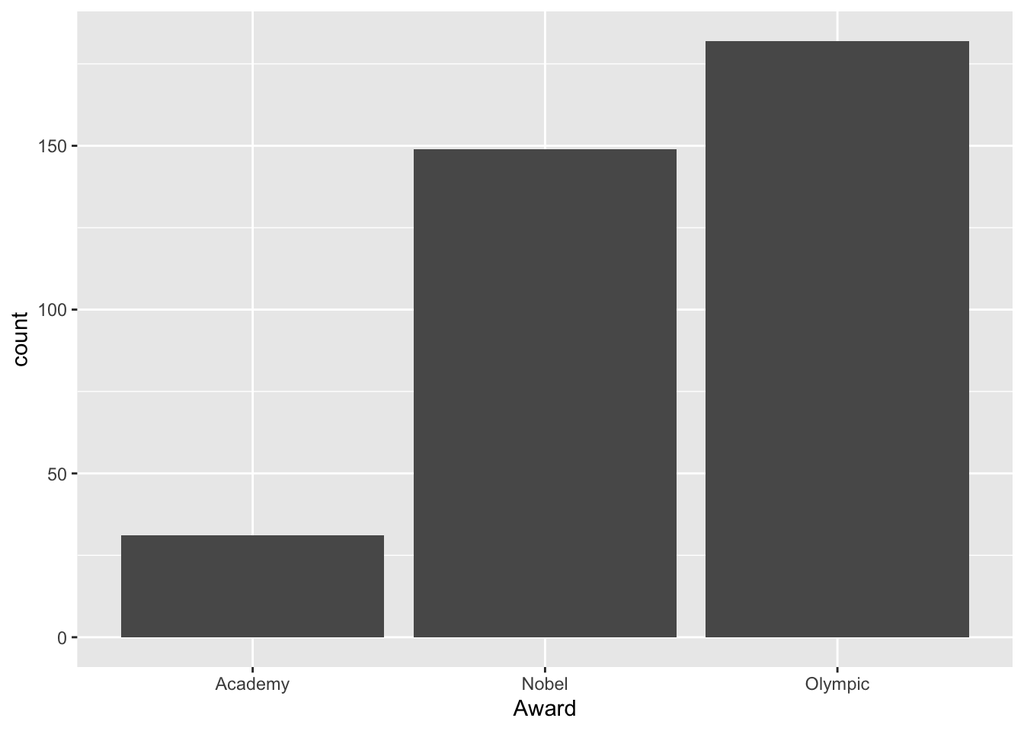

```r
gf_bar(~ Award, data = StudentSurvey)
```

bar graph, bar chart, categorical plot

## Bar chart of proportions

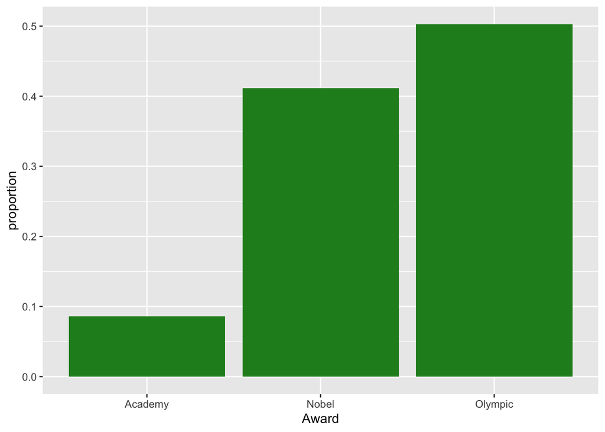

```r
gf_props(~ Award, data = StudentSurvey,
         fill = "forestgreen")
```

Use `gf_props()` for proportions rather than modifying `gf_bar()`.

proportion bar chart, percent bar graph

## Turn a bar chart sideways

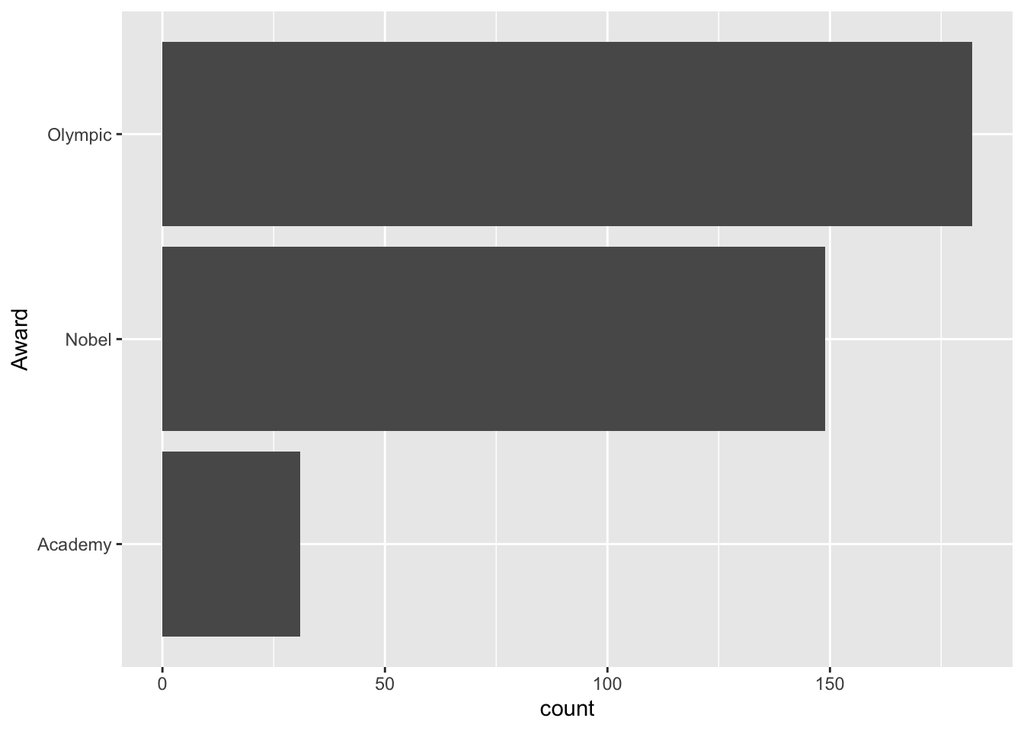

```r
gf_bar(~ Award, data = StudentSurvey) |>
  gf_refine(coord_flip())
```

Long category names are much easier to read this way.

horizontal, flip, sideways, rotate, coord_flip, long labels

## When the categories are stored as numbers

Some variables are categories even though they are recorded as `0` and `1`, or as `1, 2, 3`. `tally()` counts them correctly either way, but **plots and grouped summaries** treat them as quantitative. Wrap the variable in `factor()`:

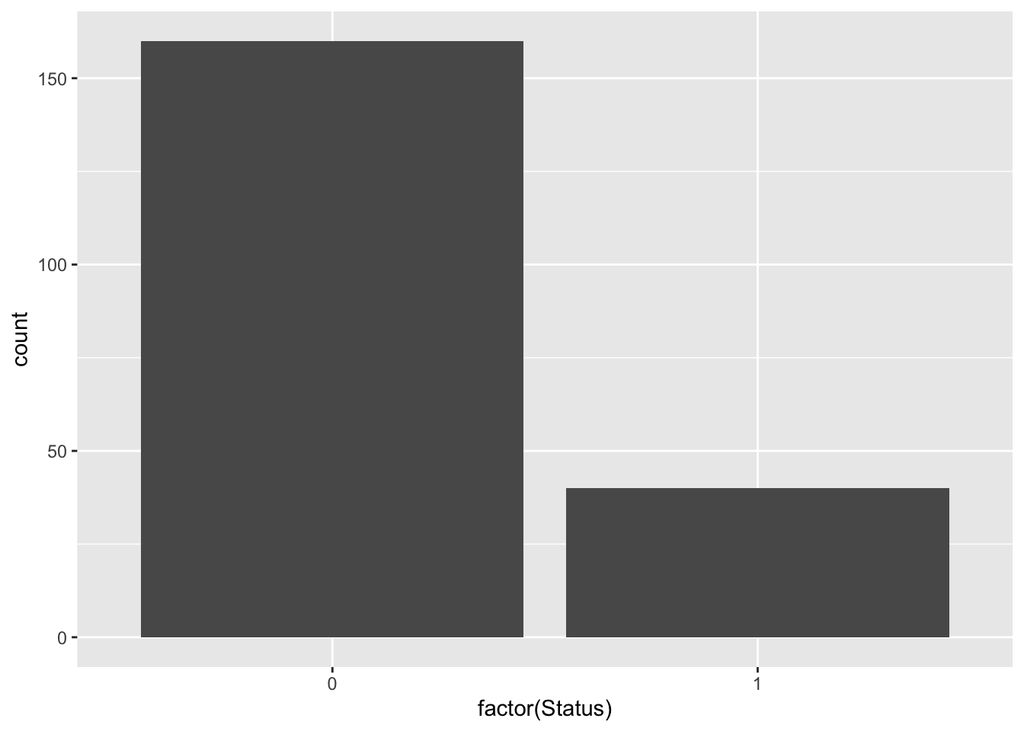

```r
gf_bar(~ factor(Status), data = ICUAdmissions)
```

Without `factor()` the bars sit on a numbered axis, as though the codes were measurements. Wrap the variable **every time it appears** — including inside `fill =` and `color =`, and in the grouped plots later in this document.

Signs you forgot: bars on a numbered axis rather than one bar per category, a boxplot with a single box instead of one per group, or a legend showing a continuous color gradient instead of separate colors.

factor, 0 1 variable, indicator, coded as numbers, numeric categorical, treat as category, as.factor, dummy, gradient legend, one box

# Two categorical variables

## Two-way table

```r
tally(~ Award + Smoke, data = StudentSurvey)
```

```
         Smoke
Award      No Yes
  Academy  29   2
  Nobel   129  20
  Olympic 161  21
```

cross tabulation, contingency table, two way, crosstab

## Conditional proportions

Put the variable you want proportions **of** on the left and the variable you want to condition **on** on the right — the same `y ~ x` pattern as everywhere else. This gives the distribution of `Award` **within** each `Smoke` group.

```r
tally(Award ~ Smoke, data = StudentSurvey,
      format = "proportion")
```

```
         Smoke
Award          No     Yes
  Academy 0.09091 0.04651
  Nobel   0.40439 0.46512
  Olympic 0.50470 0.48837
```

Each column sums to 1. Read a column top to bottom to see the breakdown of `Award` for that one `Smoke` group.

conditional, given, within group, row percent, column percent

## Grouped bar chart

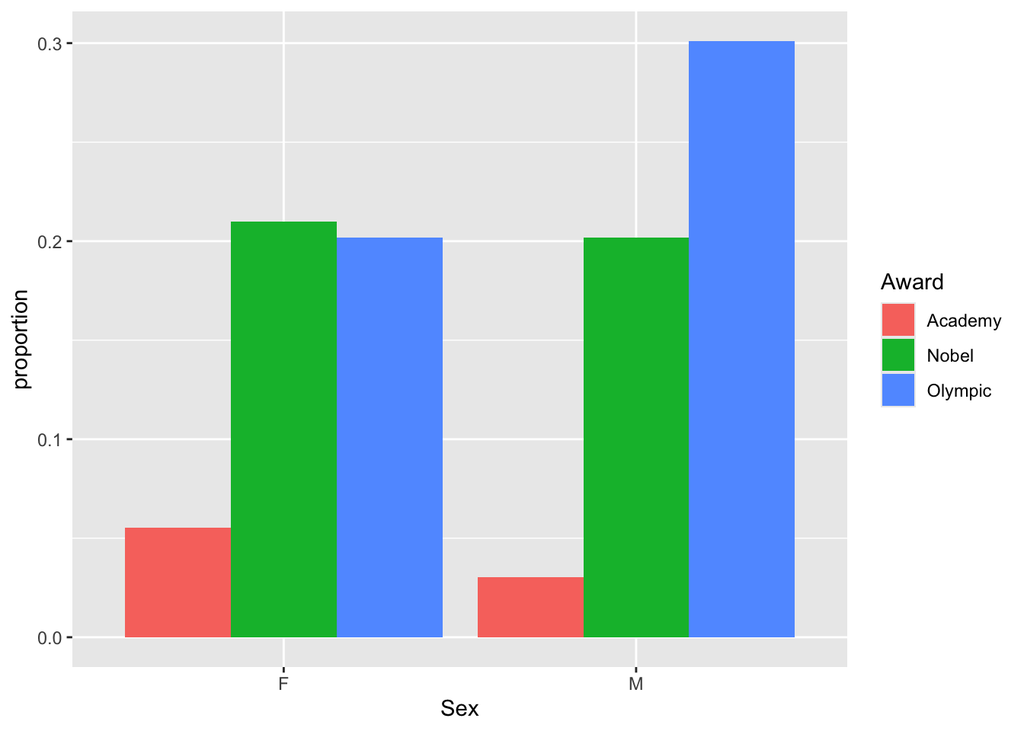

```r
gf_props(~ Sex, fill = ~ Award,
         position = "dodge",
         data = StudentSurvey)
```

side by side, grouped bars, compare groups, dodge

## Segmented bar chart

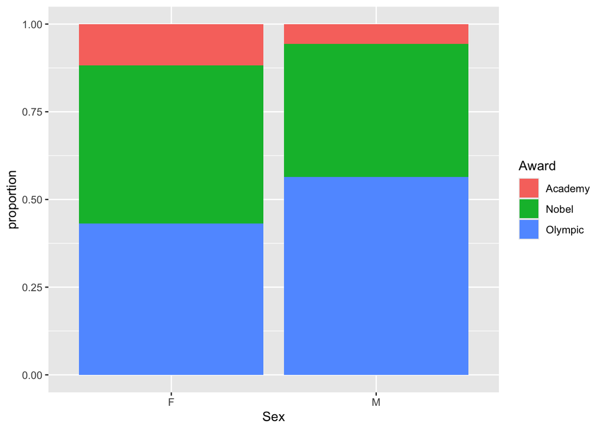

```r
gf_props(~ Sex, fill = ~ Award,
         position = "fill",
         data = StudentSurvey)
```

`position = "fill"` makes every bar the same height so you compare proportions rather than counts. Use `"stack"` if you want the raw counts stacked instead.

stacked, segmented, fill, stack, proportions by group

# One quantitative variable

## All the summary statistics at once

```r
favstats(~ Height, data = StudentSurvey)
```

```
 min Q1 median Q3 max  mean    sd   n missing
  59 65     68 71  83 68.42 4.079 355       7
```

This gives the minimum, quartiles, median, maximum, mean, standard deviation, sample size, and number of missing values. The IQR is not shown — subtract Q1 from Q3.

mean, median, average, standard deviation, sd, quartiles, five number summary, min, max, center, spread, typical, IQR, missing

## One statistic at a time

```r
mean(~ Height, data = StudentSurvey)
median(~ Height, data = StudentSurvey)
sd(~ Height, data = StudentSurvey)
IQR(~ Height, data = StudentSurvey)
quantile(~ Height, data = StudentSurvey)
```

mean, median, sd, IQR, quantile, percentile, single statistic

## Histogram

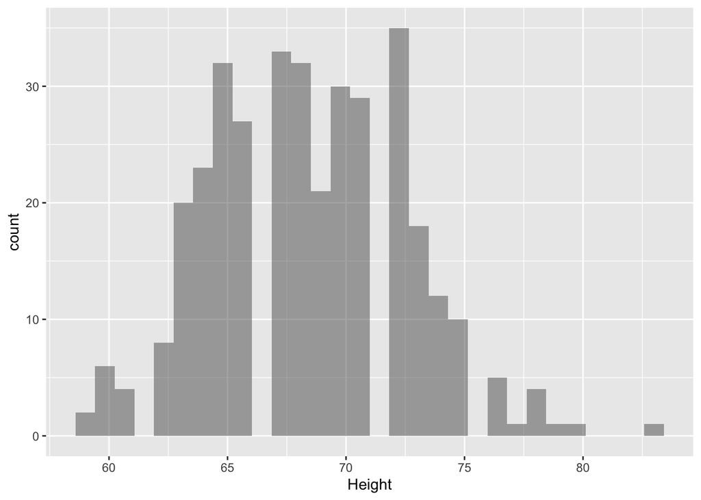

```r
gf_histogram(~ Height, data = StudentSurvey)
```

shape, distribution, skew, symmetric, plot one variable

## Histogram with a bin width you choose

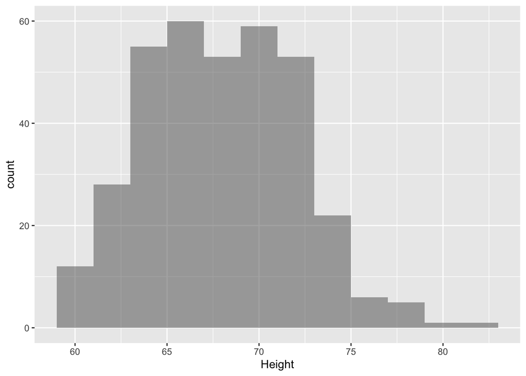

```r
gf_histogram(~ Height, data = StudentSurvey,
             binwidth = 2)
```

R picks a bin width if you do not. Changing it can change what the shape appears to be, so it is worth trying more than one.

binwidth, bins, bars, width, resolution

## Dotplot

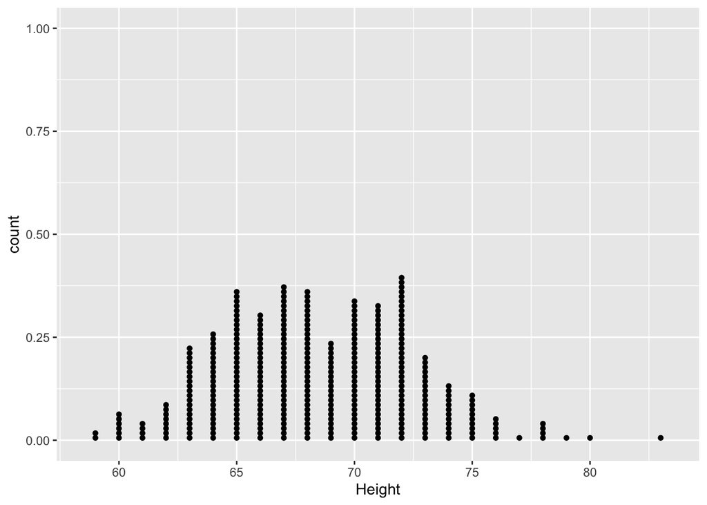

```r
gf_dotplot(~ Height, data = StudentSurvey,
           dotsize = 0.25)
```

Every dot is one observation, which makes this a good choice for small datasets. Adjust `dotsize` until the dots look reasonable — the default is often far too large.

dot plot, small data, individual values, dotsize

## Boxplot of one variable

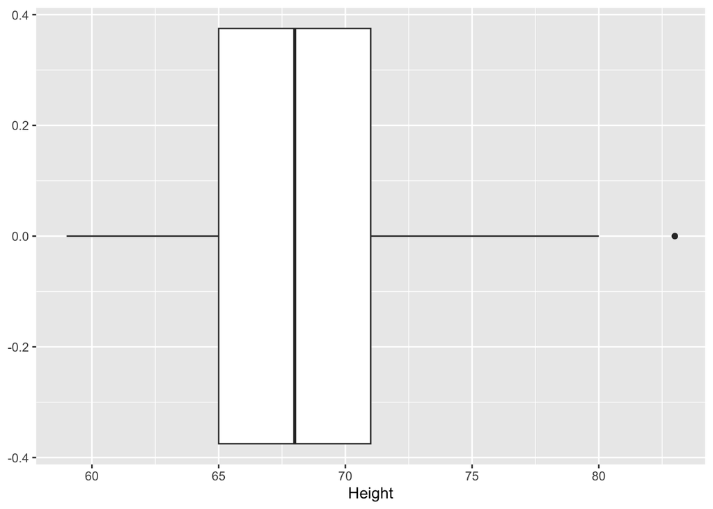

```r
gf_boxplot(~ Height, data = StudentSurvey)
```

This is already horizontal: with nothing on the left of `~`, *Height* goes on the horizontal axis. No `coord_flip()` needed — adding one would stand the box on end. The numbers on the vertical axis are meaningless here; there is only one box.

box plot, five number summary, outliers, whiskers, horizontal

# Comparing groups

## Summary statistics for each group

```r
favstats(TV ~ Sex, data = StudentSurvey)
```

```
  Sex min Q1 median Q3 max  mean    sd   n missing
1   F   0  3      4  6  20 5.237 4.100 169       0
2   M   0  3      5 10  40 7.620 6.427 192       1
```

Read `TV ~ Sex` as “TV hours described by sex”.

by group, compare, split, grouped statistics, two groups

## Side-by-side boxplots (horizontal)

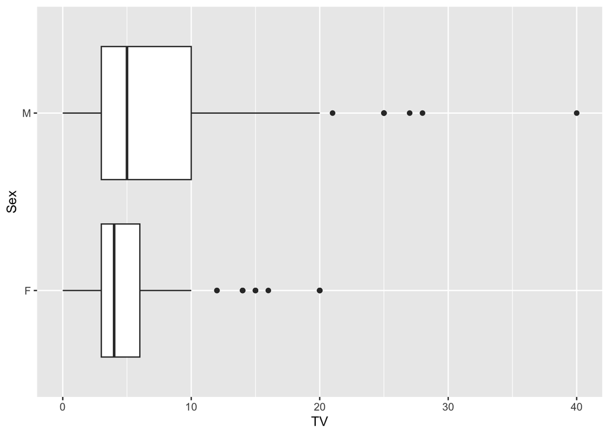

```r
gf_boxplot(Sex ~ TV, data = StudentSurvey)
```

**Why the categorical variable comes first here.** The left side of `~` is always the vertical axis. In a horizontal boxplot the groups run down the side, so the categorical variable is the vertical-axis variable and goes on the left. Horizontal is the better default: group labels stay readable, and comparing centers left-to-right is easier than comparing them up-and-down.

Note that this is the opposite order from `favstats(TV ~ Sex, ...)`, where the formula describes a relationship rather than a pair of axes.

If your grouping variable is coded as numbers rather than words, wrap it in `factor()`: `gf_boxplot(factor(Status) ~ Systolic, data = ICUAdmissions)`.

compare groups, box plot by group, horizontal, side by side, which variable first, factor

## Stacked histograms for comparing groups

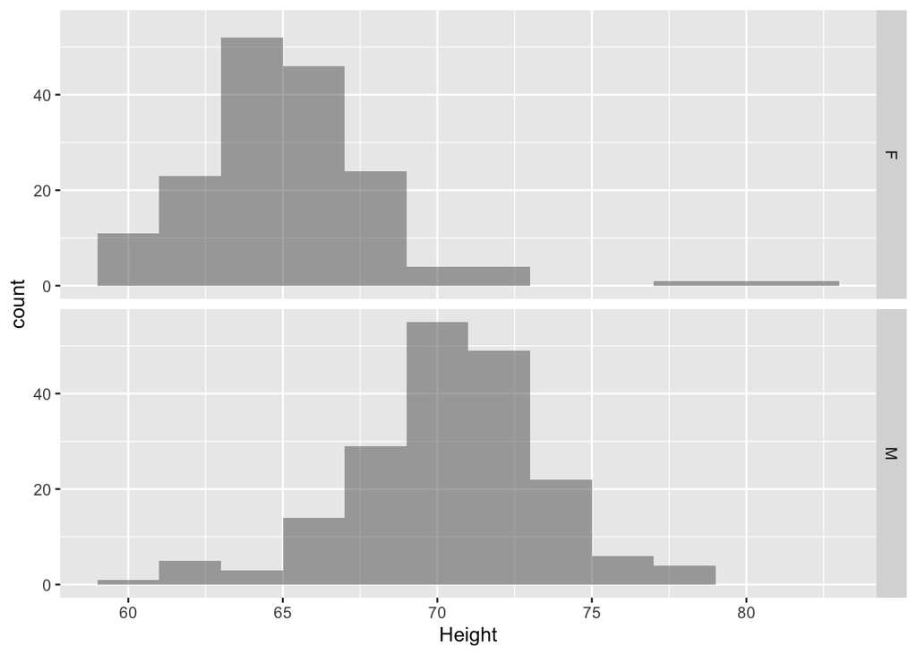

```r
gf_histogram(~ Height | Sex ~ ., data = StudentSurvey,
             binwidth = 2)
```

The `| Sex ~ .` puts each group in its own panel, stacked **vertically**. Stacking is what makes the comparison work: the panels share one horizontal scale, so centers and spreads line up directly above one another. Panels placed side by side do not let you do that.

**Why the dot?** The part after `|` is a small formula describing the *layout* of the panels — read it as **rows ~ columns**. Putting `Sex` on the left makes one row per group, so the panels stack. The `.` is a placeholder meaning “nothing here”: there is no second variable splitting the columns, but the layout formula still needs both sides. Writing `. ~ Sex` would arrange the groups side by side in columns instead, and plain `| Sex` lets R choose the arrangement for you.

Setting `binwidth` matters here too — without it the panels may not use the same bins.

faceted, panels, separate plots, vertical, stacked, by group histogram, conditioning, compare distributions, dot, layout, rows, columns

# Two quantitative variables

## Scatterplot

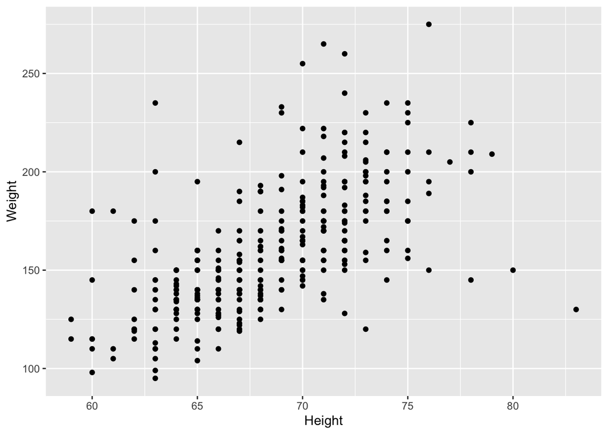

```r
gf_point(Weight ~ Height, data = StudentSurvey)
```

Read `Weight ~ Height` as “weight as a function of height”. The response goes on the left; **x** is the e**X**planatory variable and goes on the right.

scatter plot, association, relationship, x y plot, explanatory, response

## Scatterplot with a regression line

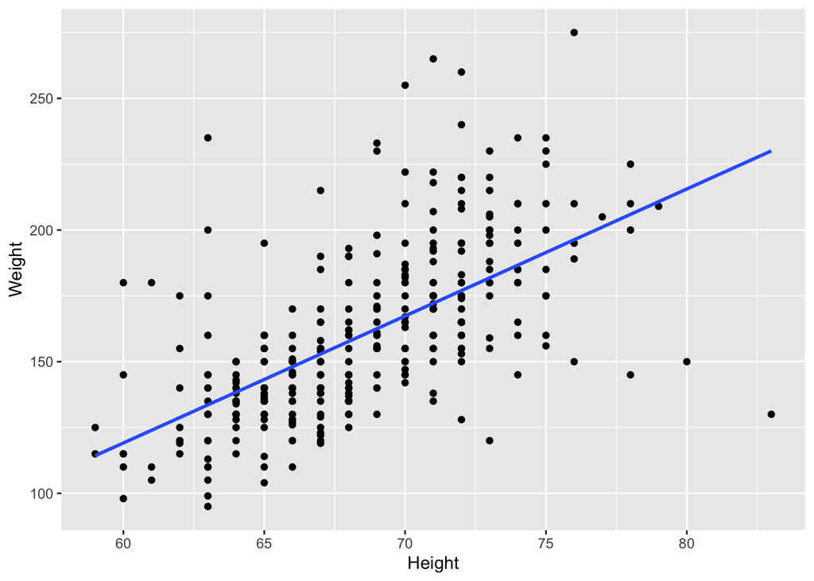

```r
gf_point(Weight ~ Height, data = StudentSurvey) |>
  gf_smooth(method = "lm")
```

Use `gf_smooth(method = "lm")` for a straight line. Leaving out `method` gives a curve that follows the data instead.

regression line, line of best fit, trend line, add line, lm

## Color the points by a categorical variable

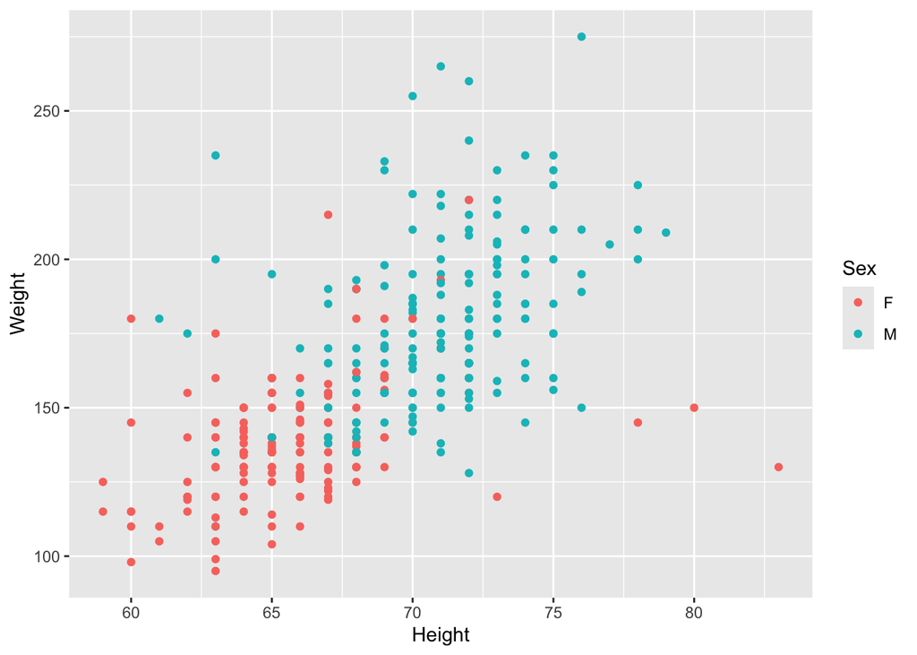

```r
gf_point(Weight ~ Height, color = ~ Sex,
         data = StudentSurvey)
```

Note the `~` in front of `Sex`. Without it, R looks for a color named “Sex”.

color by group, third variable, groups on scatterplot

## Correlation

```r
cor(Weight ~ Height, data = StudentSurvey,
    use = "complete.obs")
```

```
[1] 0.6194
```

Without `use = "complete.obs"` this returns `NA`, because some students did not report both height and weight. That argument tells R to use only the cases that have both values. Check the `missing` column of `favstats()` if you are not sure whether a variable has missing values.

correlation, r, strength, linear association, NA, missing, complete.obs

# Making a plot presentable

## Label the axes and add a title

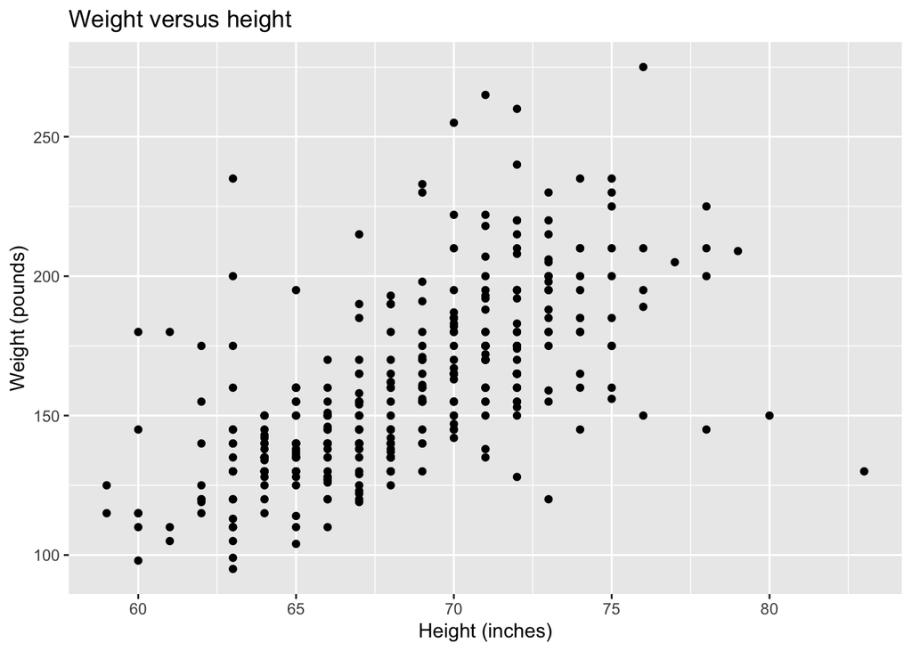

```r
gf_point(Weight ~ Height, data = StudentSurvey) |>
  gf_labs(title = "Weight versus height",
          x = "Height (inches)",
          y = "Weight (pounds)")
```

This works with any `gf_` plot. Variable names are rarely good axis labels — this is where units belong. Anything you hand in or put on a poster should have real labels.

axis labels, title, units, caption, gf_labs, label axes, presentable

## Label one or two particular points

Sometimes one point is obviously unusual and you want to say what it is — the classic example is the Palm Beach County point on a plot of Florida’s 2000 presidential vote.

Start by reading the point’s coordinates off the plot. Those coordinates are what you annotate with:

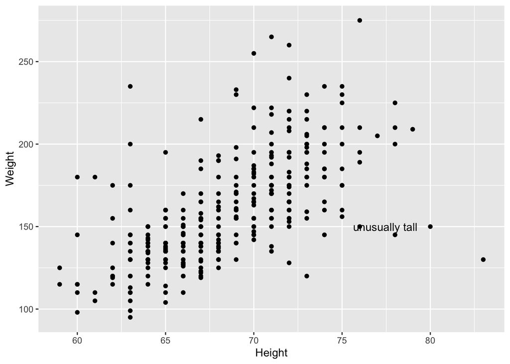

```r
gf_point(Weight ~ Height, data = StudentSurvey) |>
  gf_refine(annotate("text",
                     x = 80, y = 150,
                     label = "unusually tall",
                     hjust = 1.2))
```

`x` and `y` are the point’s own position. `hjust = 1.2` pushes the label to the **left** of that spot so it does not sit on top of the dot — use `hjust = -0.2` to put it on the right, or `vjust = -1` to put it above. Adjusting the justification rather than the coordinates keeps the label tied to the point it describes.

`annotate()` comes from ggplot2, so it has to be wrapped in `gf_refine()` to work inside a `|>` chain — the same wrapper used for `coord_flip()`.

To circle the point as well, add a second annotation **at the same coordinates**:

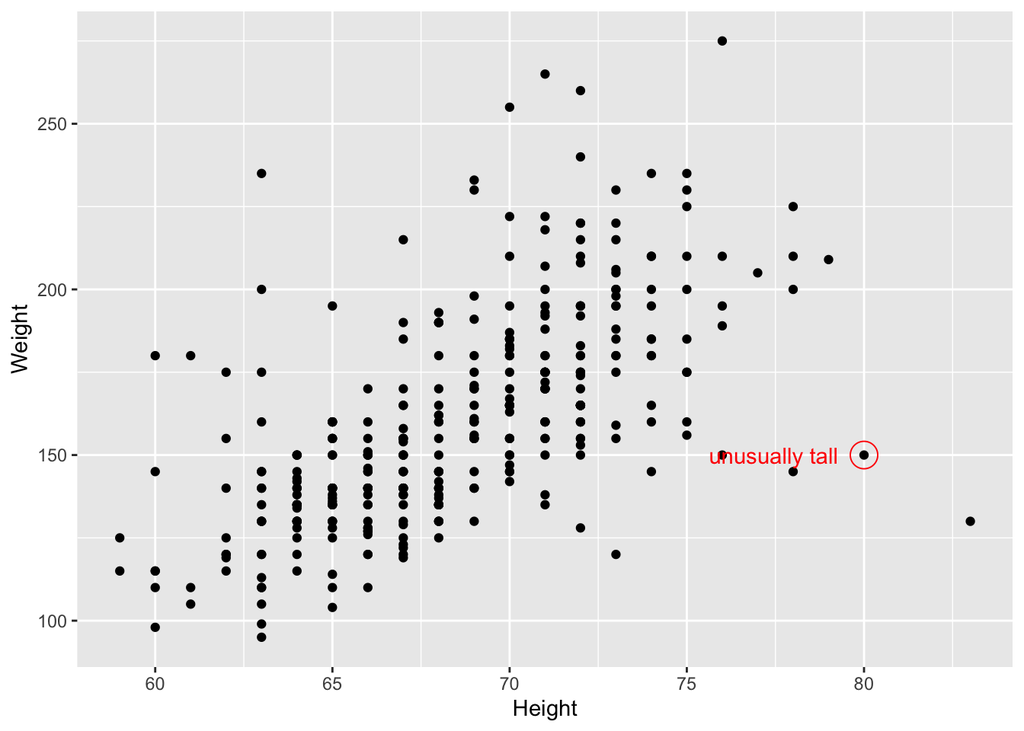

```r
gf_point(Weight ~ Height, data = StudentSurvey) |>
  gf_refine(annotate("point",
                     x = 80, y = 150,
                     shape = 1, size = 6, color = "red"),
            annotate("text",
                     x = 80, y = 150,
                     label = "unusually tall",
                     hjust = 1.2, color = "red"))
```

`shape = 1` is an open circle, so the original dot still shows through it.

label a point, annotate, text on plot, name a point, identify, which point is that, circle, mark, hjust, vjust, palm beach

# Regression

## Fit a model and see the coefficients

```r
mymodel <- lm(Weight ~ Height, data = StudentSurvey)
mymodel
```

```
Call:
lm(formula = Weight ~ Height, data = StudentSurvey)

Coefficients:
(Intercept)       Height
    -170.27         4.82
```

Printing the model object by name gives you the intercept and slope. That is all you need in this course.

lm, linear model, slope, intercept, fit, equation

## Predicted values

```r
predict(mymodel)[1:5]
```

```
    1     2     3     4     5
172.2 148.1 177.0 133.6 143.2
```

The `[1:5]` shows just the first five. Leave it off to see all of them.

prediction, fitted values, y hat, predicted

## Residuals

```r
resid(mymodel)[1:5]
```

```
      1       2       3       4       5
  7.826 -28.058  31.003 -23.589   6.765
```

residual, error, leftover, observed minus predicted

# Collecting data

## Take a random sample

```r
sample(StudentSurvey, 25)
```

random sample, sampling, select cases, survey

## Randomly assign subjects to treatment groups

First shuffle the roster into a random order:

```r
myclass <- data.frame(
  student = c("Ava", "Ben", "Cara",
              "Dan", "Eve", "Finn",
              "Gia", "Hal", "Ivy")
)

newlist <- shuffle(myclass)
head(newlist)
```

```
  student orig.id
3    Cara       3
6    Finn       6
9     Ivy       9
2     Ben       2
8     Hal       8
5     Eve       5
```

Then take the first third, the second third, and so on:

```r
# Group 1
slice(newlist, 1:3)
```

```
  student orig.id
1    Cara       3
2    Finn       6
3     Ivy       9
```

```r
# Group 2
slice(newlist, 4:6)
```

```
  student orig.id
1     Ben       2
2     Hal       8
3     Eve       5
```

```r
# Group 3
slice(newlist, 7:9)
```

```
  student orig.id
1     Gia       7
2     Ava       1
3     Dan       4
```

The shuffle is what makes the assignment random — the slicing afterward is just bookkeeping. Putting `set.seed(123)` before `shuffle()` makes the result repeatable, which is useful when you want the same groups every time you render.

random assignment, experiment, treatment groups, shuffle, slice, randomize, set.seed, experimental design

## Send data to StatKey

StatKey needs a CSV file. This writes one into your project folder, which you then upload.

```r
write.csv(StudentSurvey, "mydata.csv",
          row.names = FALSE)
```

statkey, csv, export, upload, bootstrap, randomization test, save data

# Inference

## Confidence interval and test for one mean

```r
t.test(~ Height, data = StudentSurvey)
```

```
    One Sample t-test

data:  Height
t = 316, df = 354, p-value <2e-16
alternative hypothesis: true mean is not equal to 0
95 percent confidence interval:
 68.00 68.85
sample estimates:
mean of x
    68.42
```

t test, confidence interval, one mean, CI, p-value

## Comparing two means

```r
t.test(TV ~ Sex, data = StudentSurvey)
```

```
    Welch Two Sample t-test

data:  TV by Sex
t = -4.2, df = 329, p-value = 3e-05
alternative hypothesis: true difference in means between group F and group M is not equal to 0
95 percent confidence interval:
 -3.487 -1.280
sample estimates:
mean in group F mean in group M
          5.237           7.620
```

If you have subsetted the data first with `filter()`, add `droplevels()` before running this or R may complain about groups that are no longer there.

two sample t test, difference in means, compare two groups, droplevels

# Working with your data

## Keep only some rows

```r
smokers <- filter(StudentSurvey, Smoke == "Yes")
nrow(smokers)
```

```
[1] 43
```

Use `==` for “is equal to”, not a single `=`.

filter, subset, select rows, only, exclude, condition

## Create a new variable

```r
StudentSurvey <- mutate(StudentSurvey,
                        TVperDay = TV / 7)
```

mutate, new column, compute, transform, add variable

## Basic calculation

R works as a calculator at the console: `+ - * / ^ ( )` along with `log()`, `exp()`, and `sqrt()`.

calculator, arithmetic, square root, log, exponent

# When something goes wrong

## “could not find function”

You did not load the package. Run `library(mosaic)` and try again. In a Quarto file, that line has to be in a chunk **above** the one you are running.

error, could not find function, package not loaded, library

## “object ‘Height’ not found”

You left out `data =`. R looked for a loose variable named `Height` instead of a column in your dataset.

error, object not found, data argument, variable name

## “unexpected symbol” or “unexpected ‘)’”

Usually a missing comma between arguments, or an unmatched parenthesis or quotation mark.

error, syntax, unexpected, comma, parenthesis, typo

## The answer came out as `NA`

Your variable has missing values, and the command refused to guess what to do about them. For `cor()`, add `use = "complete.obs"`. For `mean()` and similar, add `na.rm = TRUE`.

NA, missing, not available, na.rm, complete.obs, no answer

## A boxplot has one box, or a color legend is a gradient

Your grouping variable is stored as numbers (`0`/`1`, or `1, 2, 3`), so R is treating it as quantitative. Wrap it in `factor()` everywhere it appears, including inside `fill =` and `color =`.

factor, one box, gradient legend, categorical as number, 0 1, groups not separating

## The console shows `+` and will not respond

R is waiting for you to finish a command. Press **Esc** to cancel and start over.

stuck, plus sign, console, hanging, escape

## No plot appeared

Check whether you saved it to a name — `p <- gf_histogram(...)` stores the plot instead of showing it. Type `p` to display it.

plot missing, nothing happened, no output, blank

## A warning about rows being removed

Your variable has missing values. That is usually fine — it just means those cases were left out of the plot.

warning, removed rows, missing values, incomplete cases